# Retail Store Sales Analysis

Ibrahim Abdullah

2022-11-28

# Retail Store Sales Case Study

November 28, 2022 ***

# 1. Summary

The goal of this case study is to analyze a business task following through all steps of data analysis process: Ask, Prepare, Process, Analyze, Share, and Act. The business task is to analyze retail store weekly sales across different geographical areas and provide recommendations for marketing strategy. I will be using [Retail Data Analytics](https://www.kaggle.com/datasets/manjeetsingh/retaildataset) dataset that includes historical sales data of 45 stores located in different regions - each store contains a number of departments. The company also runs several promotional markdown events throughout the year.

# 2. Ask Phase

# 3. Prepare Phase

Tools which are going to be used for analysis:- 1. Microsoft Excel for exploratory analysis 2. RStudio for data cleaning 3. RStudio for data analysis and visualization

# 4. Process Phase

After inspecting the 3 data sets in Excel, we have some common attributes like Date, IsHoliday which we can use to merge the Sales and Features datasets, but first let’s upload the files in RStudio and learn more about the datasets.

```r
library(tidyverse)
library(lubridate)
library(janitor)
library(skimr)
library(psych)
```

```r
library(ggplot2)
library(reshape2)
library(DataExplorer)
library(scales)
stores <- read.csv("C:\\Users\\Ibrahim\\Desktop\\Google Data Analytics Course\\Capstone Projects\\Retail Store Data Analytics\\Dataset\\archive\\stores data-set.csv")
features <- read.csv("C:\\Users\\Ibrahim\\Desktop\\Google Data Analytics Course\\Capstone Projects\\Retail Store Data Analytics\\Dataset\\archive\\Features data set.csv")
sales <- read.csv("C:\\Users\\Ibrahim\\Desktop\\Google Data Analytics Course\\Capstone Projects\\Retail Store Data Analytics\\Dataset\\archive\\sales data-set.csv")
```

We can check how the data frames look like.

```r
head(stores)
```

```
##   Store Type   Size
## 1     1    A 151315
## 2     2    A 202307
## 3     3    B  37392
## 4     4    A 205863
## 5     5    B  34875
## 6     6    A 202505
```

```r
head(features)
```

```
##   Store       Date Temperature Fuel_Price MarkDown1 MarkDown2 MarkDown3
## 1     1 05/02/2010       42.31      2.572        NA        NA        NA
## 2     1 12/02/2010       38.51      2.548        NA        NA        NA
## 3     1 19/02/2010       39.93      2.514        NA        NA        NA
## 4     1 26/02/2010       46.63      2.561        NA        NA        NA
## 5     1 05/03/2010       46.50      2.625        NA        NA        NA
## 6     1 12/03/2010       57.79      2.667        NA        NA        NA
##   MarkDown4 MarkDown5      CPI Unemployment IsHoliday
## 1        NA        NA 211.0964        8.106     FALSE
## 2        NA        NA 211.2422        8.106      TRUE
## 3        NA        NA 211.2891        8.106     FALSE
## 4        NA        NA 211.3196        8.106     FALSE
## 5        NA        NA 211.3501        8.106     FALSE
## 6        NA        NA 211.3806        8.106     FALSE
```

```r
head(sales)
```

```
##   Store Dept       Date Weekly_Sales IsHoliday
## 1     1    1 05/02/2010     24924.50     FALSE
## 2     1    1 12/02/2010     46039.49      TRUE
## 3     1    1 19/02/2010     41595.55     FALSE
## 4     1    1 26/02/2010     19403.54     FALSE
## 5     1    1 05/03/2010     21827.90     FALSE
## 6     1    1 12/03/2010     21043.39     FALSE
```

Information about tables using glimpse function.

```r
glimpse(stores)
```

```
## Rows: 45
## Columns: 3
## $ Store <int> 1, 2, 3, 4, 5, 6, 7, 8, 9, 10, 11, 12, 13, 14, 15, 16, 17, 18, 1…
## $ Type  <chr> "A", "A", "B", "A", "B", "A", "B", "A", "B", "B", "A", "B", "A",…
## $ Size  <int> 151315, 202307, 37392, 205863, 34875, 202505, 70713, 155078, 125…
```

```r
glimpse(features)
```

```
## Rows: 8,190
## Columns: 12
## $ Store        <int> 1, 1, 1, 1, 1, 1, 1, 1, 1, 1, 1, 1, 1, 1, 1, 1, 1, 1, 1, …
## $ Date         <chr> "05/02/2010", "12/02/2010", "19/02/2010", "26/02/2010", "…
## $ Temperature  <dbl> 42.31, 38.51, 39.93, 46.63, 46.50, 57.79, 54.58, 51.45, 6…
## $ Fuel_Price   <dbl> 2.572, 2.548, 2.514, 2.561, 2.625, 2.667, 2.720, 2.732, 2…
## $ MarkDown1    <dbl> NA, NA, NA, NA, NA, NA, NA, NA, NA, NA, NA, NA, NA, NA, N…
## $ MarkDown2    <dbl> NA, NA, NA, NA, NA, NA, NA, NA, NA, NA, NA, NA, NA, NA, N…
## $ MarkDown3    <dbl> NA, NA, NA, NA, NA, NA, NA, NA, NA, NA, NA, NA, NA, NA, N…
## $ MarkDown4    <dbl> NA, NA, NA, NA, NA, NA, NA, NA, NA, NA, NA, NA, NA, NA, N…
## $ MarkDown5    <dbl> NA, NA, NA, NA, NA, NA, NA, NA, NA, NA, NA, NA, NA, NA, N…
## $ CPI          <dbl> 211.0964, 211.2422, 211.2891, 211.3196, 211.3501, 211.380…
## $ Unemployment <dbl> 8.106, 8.106, 8.106, 8.106, 8.106, 8.106, 8.106, 8.106, 7…
## $ IsHoliday    <lgl> FALSE, TRUE, FALSE, FALSE, FALSE, FALSE, FALSE, FALSE, FA…
```

```r
glimpse(sales)
```

```
## Rows: 421,570
## Columns: 5
## $ Store        <int> 1, 1, 1, 1, 1, 1, 1, 1, 1, 1, 1, 1, 1, 1, 1, 1, 1, 1, 1, …
## $ Dept         <int> 1, 1, 1, 1, 1, 1, 1, 1, 1, 1, 1, 1, 1, 1, 1, 1, 1, 1, 1, …
## $ Date         <chr> "05/02/2010", "12/02/2010", "19/02/2010", "26/02/2010", "…
## $ Weekly_Sales <dbl> 24924.50, 46039.49, 41595.55, 19403.54, 21827.90, 21043.3…
## $ IsHoliday    <lgl> FALSE, TRUE, FALSE, FALSE, FALSE, FALSE, FALSE, FALSE, FA…
```

Checking distinct store numbers and department numbers:

```r
n_distinct(stores$Store) #checking store Ids
```

```
## [1] 45
```

```r
n_distinct(features$Date) #checking before merging with sales
```

```
## [1] 182
```

```r
n_distinct(sales$Date)
```

```
## [1] 143
```

```r
n_distinct(sales$Store)
```

```
## [1] 45
```

```r
n_distinct(sales$Dept)
```

```
## [1] 81
```

There are 45 distinct store numbers but we have weekly sales data for 143 unique dates and 81 departments.

Check for NAs:

```r
sum(is.na(sales))
```

```
## [1] 0
```

```r
sum(is.na(features))
```

```
## [1] 24040
```

```r
sum(is.na(sales))
```

```
## [1] 0
```

The markdown columns in the features dataset have these NA values which we can keep for now before merging with sales dataset.

The Date column is in character format so we need to convert them into date-time format.

```r
features$Date <- as.Date(features$Date, "%d/%m/%Y")
sales$Date <- as.Date(sales$Date, "%d/%m/%Y")
```

Now we can merge features and sales data frames:

```r
features_date <- aggregate(list("Temperature" = features$Temperature, "Fuel_Price" = features$Fuel_Price, "CPI" = features$CPI, "Unemployment" = features$Unemployment), by = list("Date" = features$Date), FUN=mean, na.rm = TRUE)

features_date <- features_date %>%
  mutate(aggregate(list("IsHoliday" = features$IsHoliday), by = list("Date" = features$Date), FUN = sum, na.rm = TRUE))
```

```r
# Data is already sorted by Dates
sales_date <- aggregate(list("Weekly_Sales" = sales$Weekly_Sales), by= list("Date" = sales$Date), FUN=sum, na.rm = TRUE)
# Converting sales into Millions
sales_date$Weekly_Sales <- as.integer(sales_date$Weekly_Sales / 1000000)
```

```r
# Merging the features_date and sales_date datasets
sales_complete <- merge(sales_date, features_date, by = "Date", all.sales_date = TRUE)
head(sales_complete)
```

```
##         Date Weekly_Sales Temperature Fuel_Price      CPI Unemployment
## 1 2010-02-05           49    34.03733   2.717844 167.7309     8.619311
## 2 2010-02-12           48    34.15133   2.694022 167.8256     8.619311
## 3 2010-02-19           48    37.71978   2.672067 167.8717     8.619311
## 4 2010-02-26           43    39.24356   2.683933 167.9097     8.619311
## 5 2010-03-05           46    42.91733   2.731200 167.9476     8.619311
## 6 2010-03-12           45    47.43244   2.774422 167.9856     8.619311
##   IsHoliday
## 1         0
## 2        45
## 3         0
## 4         0
## 5         0
## 6         0
```

# 5. Analysis Phase

Let’s analyze if there are any strong correlations between attributes in the merged dataset.

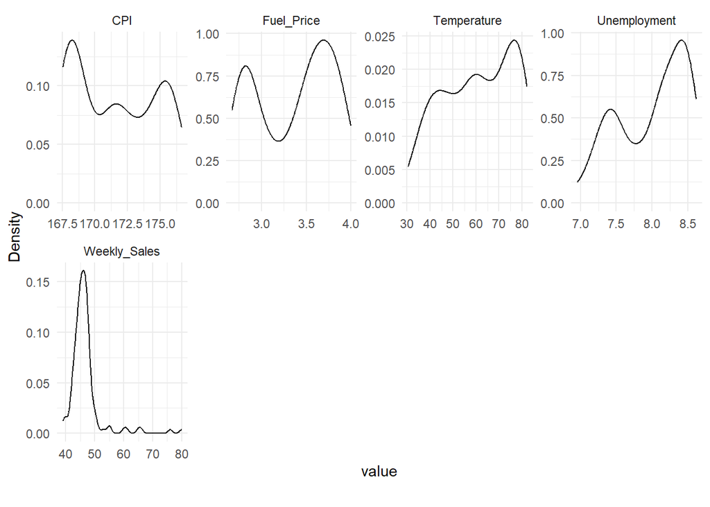

```r
# build a density plot
sales_complete %>% plot_density(ncol = 4, ggtheme = theme_minimal())
```

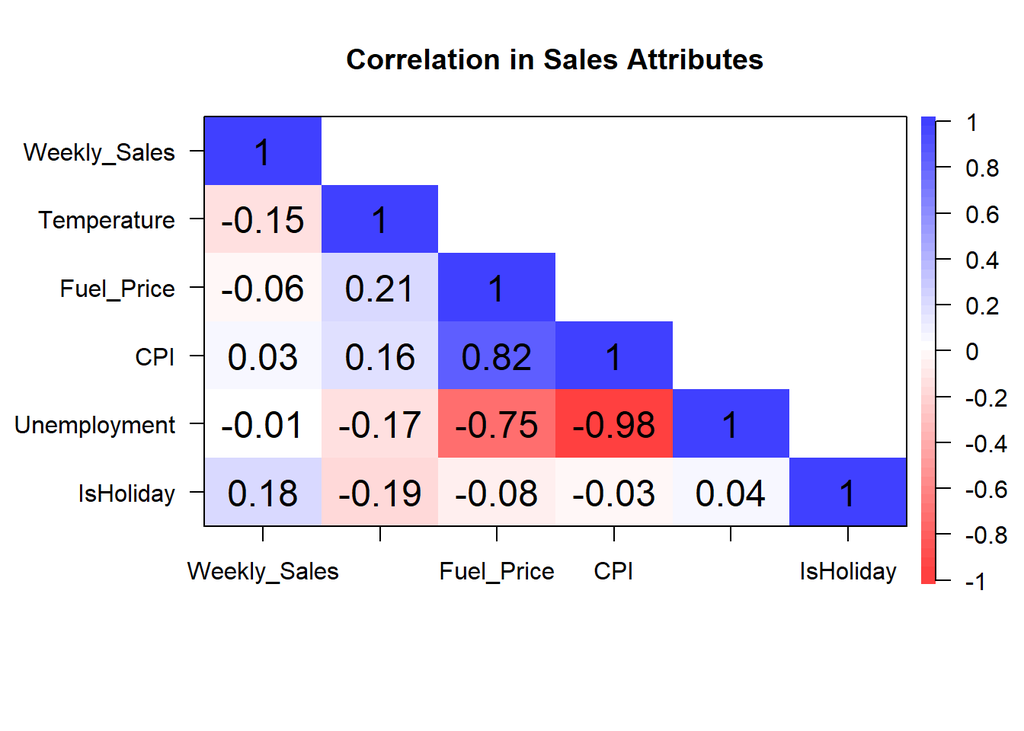

```r
# build correlation plot
corPlot(sales_complete[,2:7], upper = FALSE, scale = FALSE, main = "Correlation in Sales Attributes")
```

We can see that weekly sales does not show any strong correlation with any other parameter, but following are the major correlations found:- * Interestingly, *CPI* (which is a measure of inflation) show a strong negative correlation with *Unemployment*, which is not apparently obvious and needs further investigation if we need to draw any inference * *CPI* shows a strongly positive correlation with *Fuel_Price*, which is evident as when inflation increases, the prices of fuel would also increase. * *Unemployment* is also negatively correlated with *Fuel_Price*, this is also not very apparent and needs further investigation to draw inferences

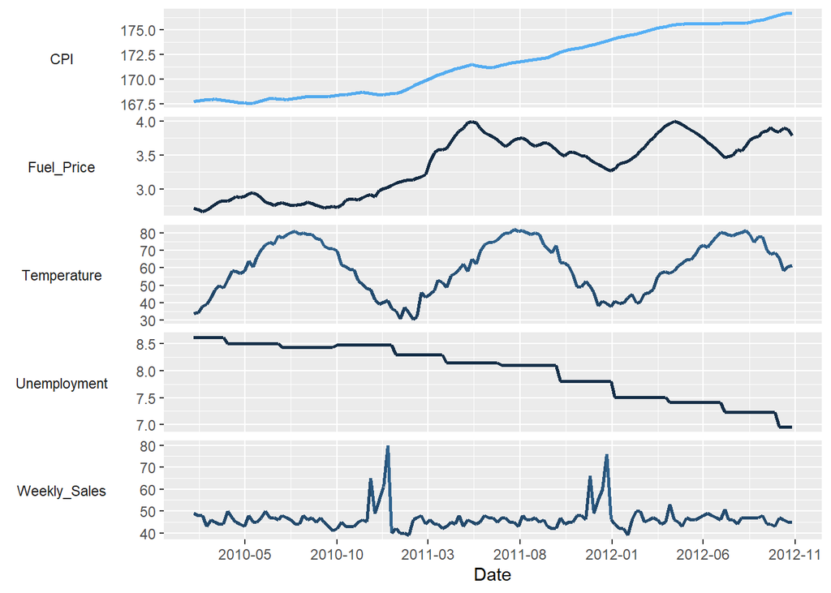

```r
plot_sales <- gather(sales_complete, "attribs", "Value", -Date, -IsHoliday)

ggplot(plot_sales, aes(Date, Value)) + geom_line(aes(color = Value), linewidth = 1) + facet_grid(attribs~., scales = "free_y", #adjust scales
                                                                                  switch = "y") + #switch y-axis labels to left
  ylab(NULL) + #remove the label "Value"
  theme(strip.background = element_blank(), #remove the background
        strip.placement = "outside", strip.text.y.left = element_text(angle = 0), legend.position = "none") + scale_x_date(date_breaks = "5 months", date_labels = '%Y-%m')
```

- Average weekly sales tend to shoot up in the last two months of the year but overall remain almost constant through out the year.
- Fuel price and CPI (Consumer Price Index) increased over the years from 2010 till the end of 2012.
- Unemployment rates have decreased year after year at an almost constant rate.
- Temperature changes in a constant pattern round the year as expected from seasonal changes.

We can further check if there is any specific months when the weekly sales are generally higher.

```r
sales_monthly <- sales_complete %>% group_by(month = lubridate::floor_date(Date, "month")) %>% summarize("Weekly_Sales" = sum(Weekly_Sales))

sales_monthly <- sales_monthly %>% mutate(Month = as.integer(lubridate::month(month)), Year = lubridate::year(month)) %>% group_by(Month) %>%
  summarize("Sales" = sum(Weekly_Sales))
```

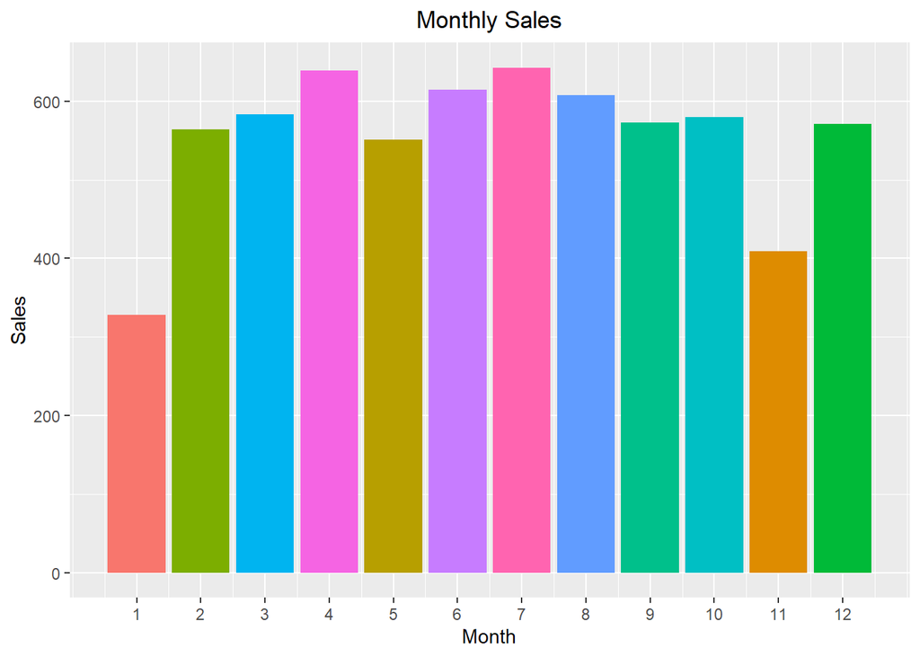

```r
ggplot(sales_monthly, aes(x = Month, y = Sales, fill=as.factor(Sales))) + geom_col() + guides(fill="none") + scale_x_continuous(breaks = c(1,2,3,4,5,6,7,8,9,10,11,12)) + scale_fill_discrete() + labs(title = "Monthly Sales")+ theme(plot.title = element_text(hjust = 0.5))
```

* During the 3 year period, it can be observed that the sales in the month of November are lower as people wait for year-end sales in December as it could be a pre-holidays shopping for festivals like Christmas and New Year and after a heavy shopping spree in December, sales dip lower again in January due to holidays.

- Monthly total sales stay high around the year with peaks in April and July suggesting high customer spending behaviour in late spring and summer months.

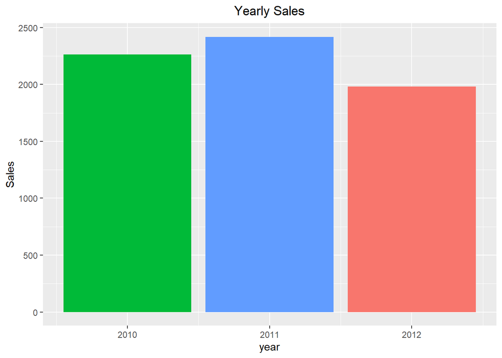

```r
sales_yearly <- sales_complete %>% group_by(year = lubridate::floor_date(Date, "year")) %>% summarize("Sales" = sum(Weekly_Sales))

ggplot(sales_yearly, aes(x = year, y = Sales, fill=as.factor(Sales))) + geom_col() + guides(fill="none") + scale_fill_discrete() + labs(title = "Yearly Sales")+ theme(plot.title = element_text(hjust = 0.5))
```

We can further investigate if there is any trend or correlation with different store types.

```r
stores_agg <- aggregate(list("Temperature" = features$Temperature, "Fuel_Price" = features$Fuel_Price), by = list("Store" = features$Store), FUN=mean, na.rm = TRUE)

stores_agg <- stores_agg %>% mutate(aggregate(list("IsHoliday" = features$IsHoliday), by = list("Store" = features$Store), FUN=sum, na.rm = TRUE))

temp_store <- aggregate(list("Weekly_Sales" = sales$Weekly_Sales), by = list("Store" = sales$Store), FUN=sum, na.rm = TRUE)

temp_store$Weekly_Sales <- as.integer(temp_store$Weekly_Sales / 1000000)

stores <- stores %>% mutate("Temp" = stores_agg$Temperature)
stores <- stores %>% mutate("Fuel_Price" = stores_agg$Fuel_Price)
stores <- stores %>% mutate("Holiday" = stores_agg$IsHoliday)
stores <- stores %>% mutate("Weekly_Sales" = temp_store$Weekly_Sales)

str(stores)
```

```
## 'data.frame':    45 obs. of  7 variables:
##  $ Store       : int  1 2 3 4 5 6 7 8 9 10 ...
##  $ Type        : chr  "A" "A" "B" "A" ...
##  $ Size        : int  151315 202307 37392 205863 34875 202505 70713 155078 125833 126512 ...
##  $ Temp        : num  66.9 66.7 70.4 61.4 68.2 ...
##  $ Fuel_Price  : num  3.26 3.26 3.26 3.25 3.26 ...
##  $ Holiday     : int  13 13 13 13 13 13 13 13 13 13 ...
##  $ Weekly_Sales: int  222 275 57 299 45 223 81 129 77 271 ...
```

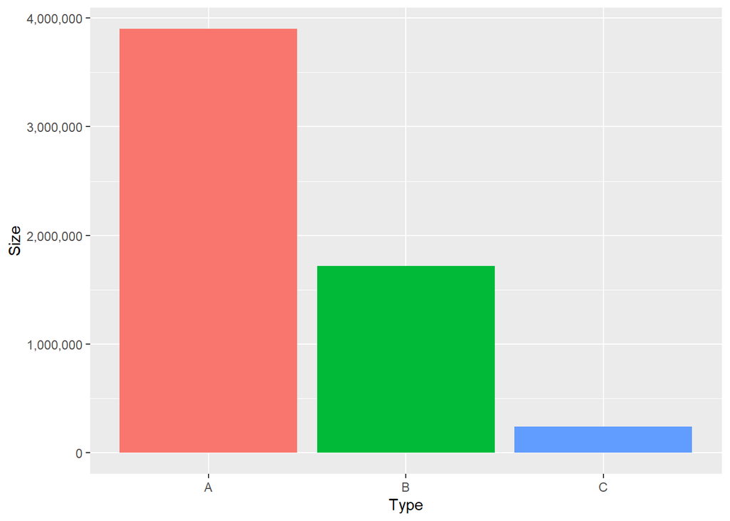

```r
ggplot(stores, aes(x = Type, y = Size, fill = Type)) +  geom_col() + guides(fill="none") + scale_y_continuous(labels=comma)
```

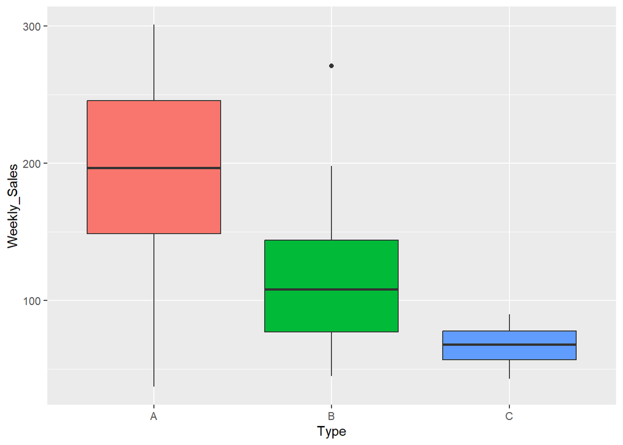

```r
ggplot(stores, aes(x = Type, y = Weekly_Sales, fill = Type)) + geom_boxplot() + guides(fill="none")
```

- Type A stores are the largest with highest sales, followed by B and then C.
- We can notice a relationship between the size of retail stores and the weekly sales, the bigger the size of the store, higher the weekly sales, however, stores of Type B, being of smaller sizes than type A, have higher minimum weekly sales than store A.

Next, we will try to find any relationship of weekly sales with different store departments.

```r
# Checking number of unique departments
n_distinct(sales$Dept)
```

```
## [1] 81
```

```r
#Grouping departments by sales
dept_data <- aggregate(list("Weekly_Sales" = sales$Weekly_Sales), by = list("Dept" = sales$Dept), FUN=sum, na.rm = TRUE)

dept_data$Weekly_Sales <- as.integer(dept_data$Weekly_Sales / 1000000)

dept_data[order(dept_data$Weekly_Sales),]
```

```
##    Dept Weekly_Sales
## 38   39            0
## 42   43            0
## 44   45            0
## 46   47            0
## 50   51            0
## 52   54            0
## 63   77            0
## 64   78            0
## 81   99            0
## 47   48            2
## 57   60            2
## 27   28            3
## 49   50            4
## 56   59            4
```

[output cut: 67 more lines]

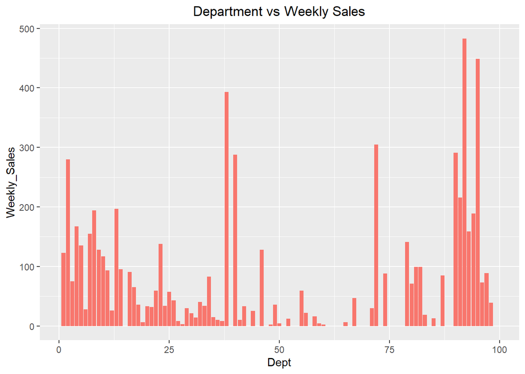

```r
ggplot(dept_data, aes(x = Dept, y = Weekly_Sales, fill = "light pink")) + geom_col() + labs(title = "Department vs Weekly Sales") + theme(plot.title = element_text(hjust = 0.5)) + guides(fill="none")
```

```r
dept_data[which.max(dept_data$Weekly_Sales),]
```

```
##    Dept Weekly_Sales
## 74   92          483
```

```r
dept_data[which.min(dept_data$Weekly_Sales),]
```

```
##    Dept Weekly_Sales
## 38   39            0
```

```r
dept_data[dept_data$Weekly_Sales == 0,]
```

```
##    Dept Weekly_Sales
## 38   39            0
## 42   43            0
## 44   45            0
## 46   47            0
## 50   51            0
## 52   54            0
## 63   77            0
## 64   78            0
## 81   99            0
```

Some key observations:-

- Departments 90 to 95 have high weekly sales, (dept. 92 having the highest of all departments with 483 million (currency not specified in the data source)). Departments 2, 38, 40 and 72 also in particular have higher sales than their neighboring departments.
- 9 departments have zero sales (dept. 39, 43, 45, 47, 51, 54, 77, 78, 99)

Moving on to *markdowns*:

Typically, markdowns are expressed in [percentages](https://www.indeed.com/career-advice/career-development/how-to-calculate-markdown) but in this data set it is not clearly specified so I am assuming the markdown values expressed in terms of absolute price differences.

```r
# Aggregate weekly sales by Date and Store
sales_date_store <- aggregate(list("Weekly_Sales" = sales$Weekly_Sales), by = list("Date" = sales$Date, "Store" = sales$Store), FUN=sum, na.rm = TRUE)
# Converting weekly sales into millions
sales_date_store$Weekly_Sales <- as.integer(sales_date_store$Weekly_Sales / 1000000)
# Merging features data set with sales_date_store
sales_stores_combined <- merge(features, sales_date_store, by = c("Date", "Store"), all.features = TRUE)
```

```r
# Adding Store number and type column in the sales_stores_combined dataset
sales_stores_combined <- merge(sales_stores_combined, stores[c("Store", "Type")], by = "Store", all.sales_stores_combined = TRUE)

sales_stores_combined <- sales_stores_combined[,-15:-19]
# Omitting all NA values
clean_sales_stores <- na.omit(sales_stores_combined)
# Aggregating average markdown values by Date
markdowns <- aggregate(list("Markdown1" = clean_sales_stores$MarkDown1, "Markdown2" = clean_sales_stores$MarkDown2, "Markdown3" = clean_sales_stores$MarkDown3, "Markdown4" = clean_sales_stores$MarkDown4), by = list("Date" = clean_sales_stores$Date), FUN=mean, na.rm = TRUE)
```

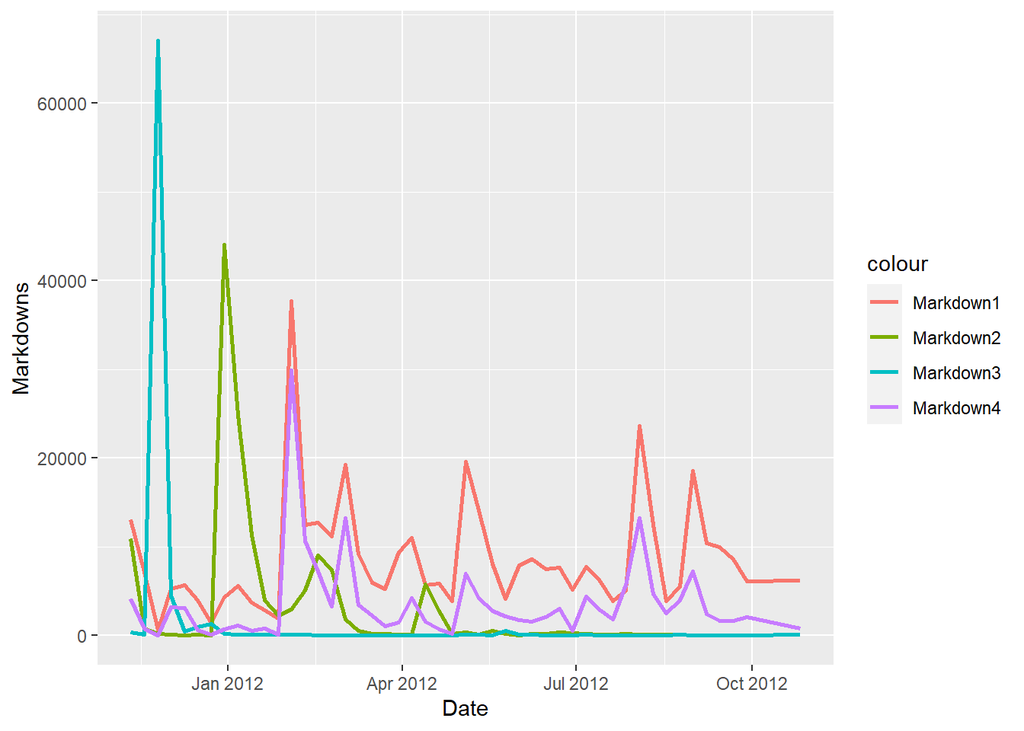

```r
# Plotting the markdowns as trending lines

ggplot(markdowns, aes(x = Date, y = Markdowns)) + geom_line(aes(y = Markdown1, colour = "Markdown1"),  linewidth = 1) + geom_line(aes(y = Markdown2, colour = "Markdown2"),linewidth = 1) + geom_line(aes(y = Markdown3, colour = "Markdown3"),linewidth = 1) + geom_line(aes(y = Markdown4, colour = "Markdown4"),linewidth = 1)
```

More information on the types of markdowns is needed to draw any concrete inferences.

# 6. Conclusion

# 7. References

- [Bellabeat Case Study](https://www.kaggle.com/code/yuliamur/bellabeat-case-study-capstone-project)
- [Retail Data Analysis](https://www.kaggle.com/code/shubhamsinghgharsele/retail-data-analysis)
- [Markdowns](https://www.indeed.com/career-advice/career-development/how-to-calculate-markdown)
- [CPI](https://www.investopedia.com/terms/c/consumerpriceindex.asp)